# A Social Network Analysis of Language Use in the Multilingual Study Abroad Context

10/24/2020

## Motivation

- Social network has great impacts on language learning in the study abroad context (Dewey 2017; Gautier, 2017; Isabelli-García, 2006; Shiri, 2015).
- Ego-centric network studies suggest that study abroad students lack critical access to out-of-classroom social networks and thereby they tend to interact with other students in the same cohort (Dewey, 2013; Shiri, 2015).
- Little work has been done to examine the internal interaction of study abroad students.
- Given that prior studies focus on ego-centric networks, it also fails to examine how broad network structure shapes students’ language learning.

## Our solution

- We developed a novel *Study Abroad Complete Network Questionnaire* to collect students’ complete or whole network data.
- We collected SACNQ in a small-size (38) study abroad program in China.

## Here is a preview of SACNQ.

- We first obtained a list of students in the target cohort we were studying.
- We then asked study abroad students to identify each student they frequently talk to in their cohort.
- We further asked students to evaluate each selected student’s language use.
- We also collected each student’s demographic information.
- We further conducted a 6-month ethnographic work to assess the validity of students’ self-reported network from SACNQ.

## What do we have in SACNQ?

- Ego-centric network approach
  - List up to a limited number of persons students frequently talk to
  - Incomplete network
- Complete network approach
  - Strength: collect information for each pair of students in the cohort
  - Weakness: difficult to scale-up (appropriate for small group)

## Here is a snapshot of network data

```r
load("sacnq.RData")
knitr::kable(sacnq_edges[1:2,1:8])
```

| from | to | w1_freq | w2_chn | w3_en | w4_oth_lang | w5_chn_pro | w6_en_pro |
| --- | --- | --- | --- | --- | --- | --- | --- |
| 1 | 2 | 1 | 5 | 95 | NA | 3 | 5 |
| 1 | 5 | 2 | 5 | 95 | NA | 2 | 5 |

```r
knitr::kable(sacnq_attrs[1:2,c(1,3:8)])
```

| name_id | pseudo_name | gender | nation | region | month | chn_pro_self_report |
| --- | --- | --- | --- | --- | --- | --- |
| 1 | Tiffany | F | USA | North America | 10 | Imd |
| 2 | Hana | F | Korea | Asia | 22 | Imd |

## Let us visualize the speaker network first.

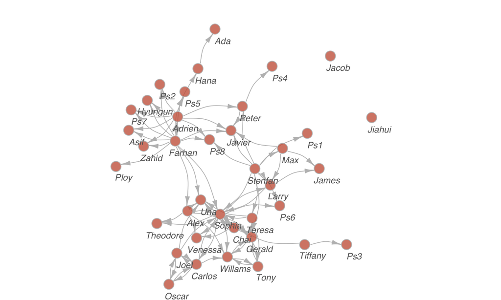

## Let us see the popularity of students.

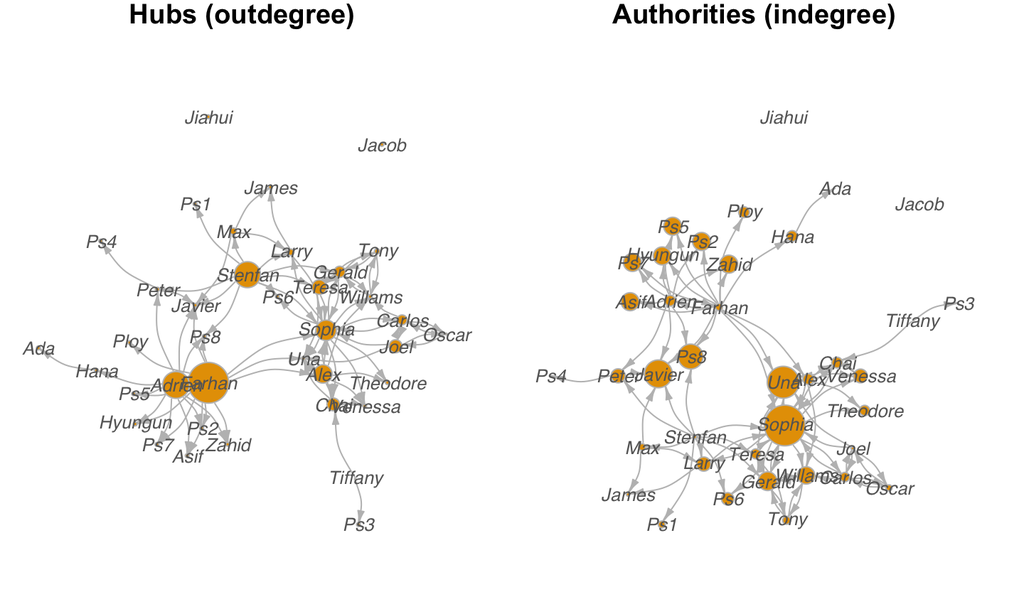

## Let us explore SA students’ language use.

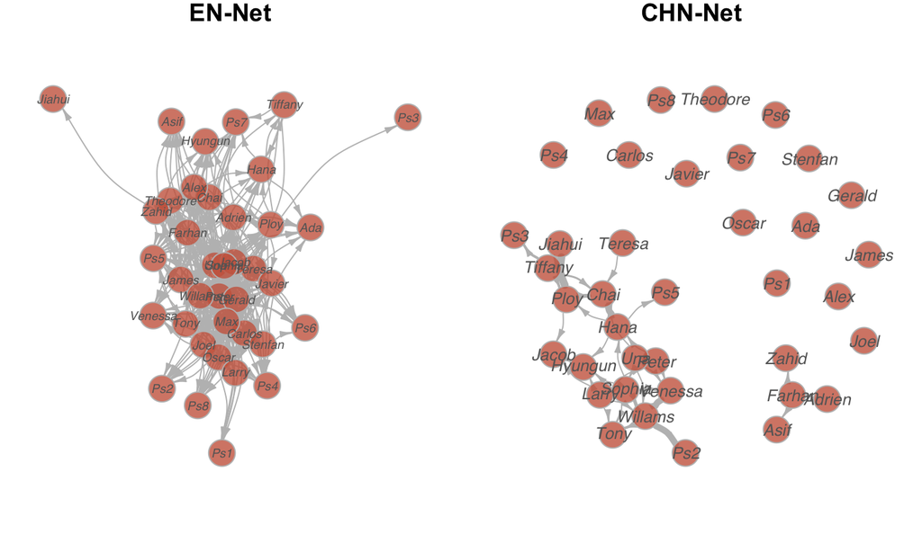

## Let us take a deep look at Chinese Net.

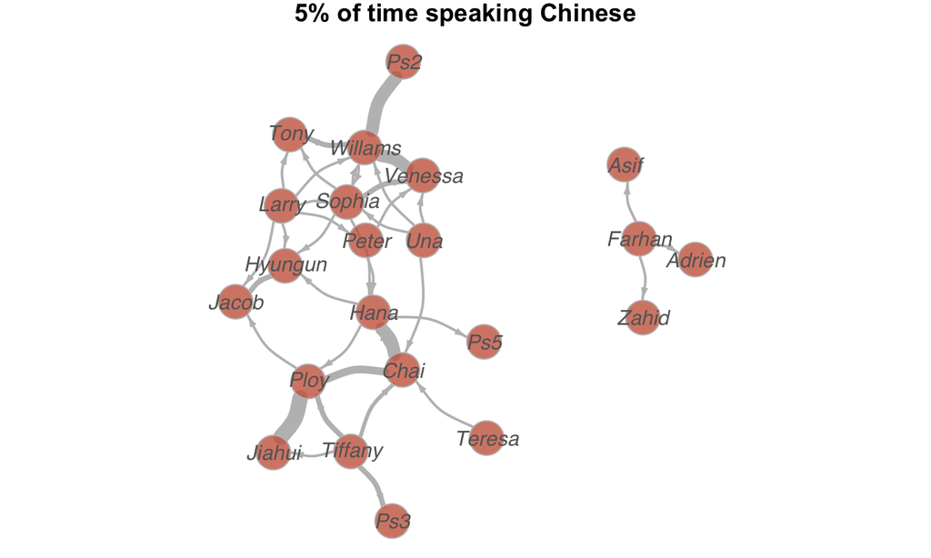

## Do network structure and students’ attributes influence language use?

- We can use exponential random graph model (ERGM) to estimate the Chinese speaking network formation.

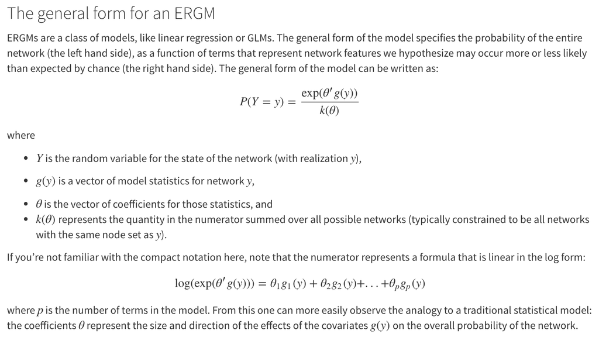

## Here is the ERGM output.

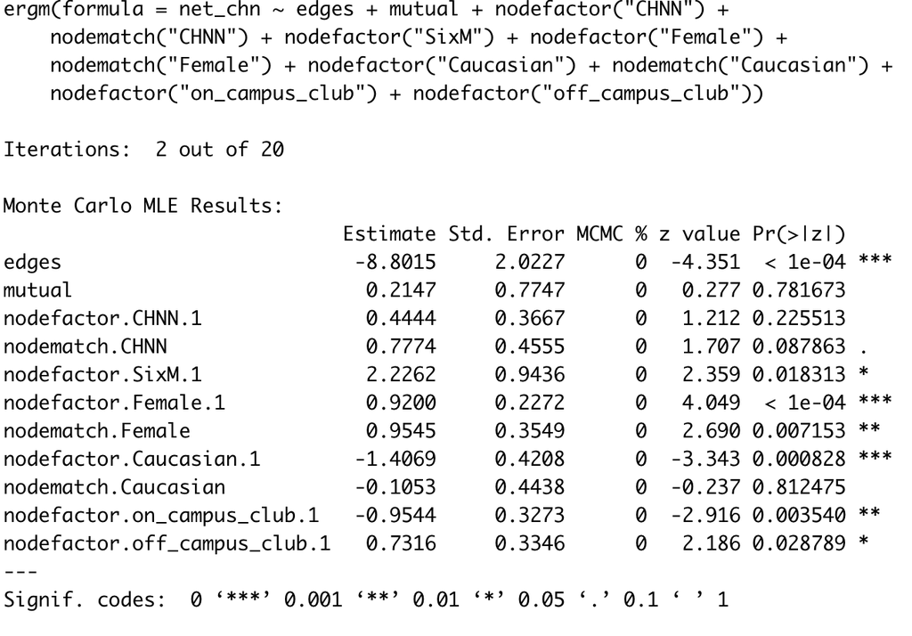

## What does ERGM tell us?

- SA students with near native or native level tend to speak with other cohort students with high level of Chinese.
- SA students staying in China for at least half year are also more likely to use Chinese in their interaction with other students.
- Female SA students tend to use Chinese in their interaction.
- Female SA students also tend to talk with female students using Chinese.
- Caucasians are less likely to use Chinese.
- SA students with on-campus activities are less likely to use Chinese interacting with their cohort members.
- SA students with off-campus activities tend to use Chinese when they interact with other cohort members

## We use ethnographic work to validate our SACNQ.

- Ethnographic data show similar pattern.

## Some Caveats and Challenges

- Data collection may encounter unexpected problems.
- Difficult to Scale-up.